# Interactive exploration with gripui

Installed figures use static projections. To enable 3D rotation and layout selection, render with `options(grip.vignette.interactive = TRUE)` and **ivue** and **rgl** installed.

The project explorer lets you select saved layouts, inspect their scores, and rotate the selected graph. The graph-family explorer instead constructs synthetic examples from parameters. Both are optional Shiny applications.

## Prepare an application graph

This walkthrough uses the same **dwt_307** graph as Getting Started. Two presets and two seeds provide a small collection to browse.

```r
g <- suitesparse.graph('dwt_307')
cmp <- compare.layouts(edges=g$edges,n=g$n,dim=3,
  candidates=c('default','tree'),seeds=1:2,return.layouts=TRUE,
  edge.crossings='never')
adj <- vector('list',g$n)
for(i in seq_len(nrow(g$edges))) {
  a <- g$edges[i,1];b <- g$edges[i,2]
  adj[[a]] <- c(adj[[a]],b);adj[[b]] <- c(adj[[b]],a)
}
project <- gripui.project.from.compare(cmp,
  graph=list(adj_list=adj),title='dwt_307: presets and seeds')
gripui.validate.project(project)
```

## Launch and explore

```r
run.gripui(project)
```

The app requires **shiny**, **bslib**, **DT**, **htmltools**, and **rgl**, all listed as optional dependencies of grip. Launching it is an interactive step; building this vignette does not start a server.

| Step | What to do | What to inspect |
| --- | --- | --- |
| 1. Choose a result | Select a row in the layout catalog | Candidate, seed, status, and available coordinates |
| 2. Inspect the drawing | Rotate the graph and compare another row | Branches, folds, and crowded regions |
| 3. Read the scores | Compare the score landscape and table | Distance agreement alongside visual differences |
| 4. Check stability | Compare seeds within a candidate | Whether the apparent structure persists |

The figure below previews two layouts from this project. It is an ivue figure, not a screenshot of the Shiny application. The app provides the catalog and score-selection workflow described above.

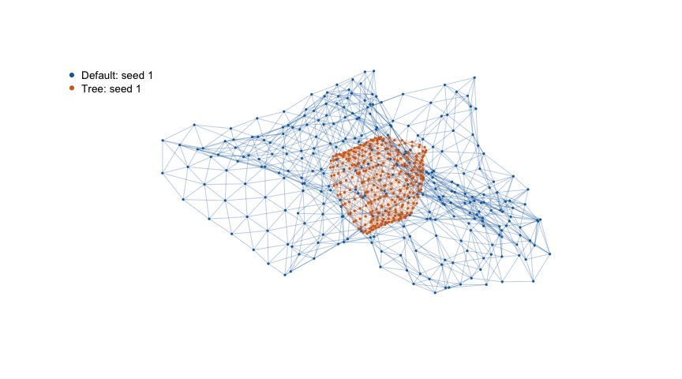

Saved project layouts: default and tree GRIP presets. Rigid alignment; no resizing.

```r
knitr::kable(project$layouts[,c('layout_id','candidate','seed','status','availability')])
```

| layout_id | candidate | seed | status | availability |
| --- | --- | --- | --- | --- |
| compare_default_seed_001 | default | 1 | ok | interactive |
| compare_default_seed_002 | default | 2 | ok | interactive |
| compare_tree_seed_001 | tree | 1 | ok | interactive |
| compare_tree_seed_002 | tree | 2 | ok | interactive |

## Explore graph families

For a new synthetic construction rather than saved layout results, launch:

```r
run.gripui.family()
```

Choose a graph family, alter its construction parameters, and inspect its geometry. The graph gallery introduces the families and their ordinary R recipes; the function overview lists all interactive exploration functions.

## Import existing results

Use `gripui.project()` to assemble results from another source, or `gripui.project.from.dir()` to read an existing output directory. Keep vertex ordering consistent between graph data and every coordinate matrix.

```r
project <- gripui.project.from.dir(root='/path/to/saved/outputs',
  title='My saved search')
gripui.validate.project(project)
run.gripui(project)
```

The function help documents the project fields and directory structure. For layout selection principles, see Choosing and evaluating.